# Connecting RStudio to GitHub

Git

GitHub

Reproducibility

Gitting serious about version control

Erika Duan  
05-30-2021

# Introduction

This is a post about a housekeeping activity that keeps your coding projects reproducible and collaboration friendly. Automating version control may be an unglamourous activity, but it will prevent your team from sinking into a swamp of messy code.

# Let’s talk about SSH

The story of connecting to a remote GitHub repository begins with a segue into the [Secure Shell (SSH) protocol](https://searchsecurity.techtarget.com/definition/Secure-Shell). SSH is a cryptographic network protocol that enables secure communication, such as file transfers and remote device management, between a local machine and a remote host over an open network.

SSH uses public-private key pairs to authenticate hosts to server communication. This involves:

- A public key, added to your GitHub profile, to authenticate the remote machine to the local machine.
- A private key to authenticate your local machine to the remote machine.

**Note:** Using SSH keys allows you to connect to GitHub without having to supply your username and password each time you push to GitHub.

# Create a new SSH key from RStudio

1. Navigate to `Tools > Global Options > Git/SVN` and check whether you have an existing SSH RSA key.
2. Click `Create RSA key`. RStudio will create an SSH key pair and store your identification and public key in the files `~/.ssh/id_rsa` and `~/.ssh/id_rsa.pub` respectively.
3. Click `Apply` and `OK` to close the `Global Options` window.

**Note:** You should always protect your private key with a passphrase as an additional layer of security. RStudio will also automatically add your key to the SSH agent, which saves you from entering your passphrase every time you use your SSH key.

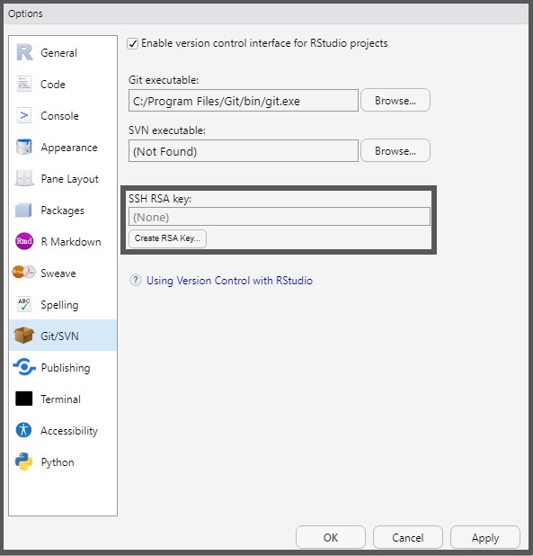

3. Navigate back to `Tools > Global Options > Git/SVN` and click `View public key` to copy your public key to clipboard (or an open text file). You may need to restart RStudio for your SSH key pair to be detected.

[figure not shown]

4. Navigate to https://GitHub.com/ and log into your GitHub account. Click on your profile icon on the top right corner of your browser and navigate to `Settings > SSH and GPG keys`. Click `New SSH key` and paste your previously copied public key into the box.

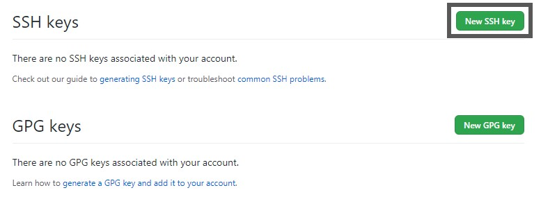

5. Add an informative title like the current year and device that you are using i.e. `2021-lenovo-lt` and create your new SSH key. Congratulations! You have now connected to your remote GitHub repositories via RStudio.

# Update GitHub repository from RStudio

1. To check your remote connection, open a local Git repository and make some file changes. Navigate to the `Git` tab in RStudio, which is localised next to the `Environment` and `History` tabs. New file modifications will be marked by `M` or `?` icons to denote modified file changes or newly added i.e. untracked files respectively.

[figure not shown]

**Note**: New file modifications will only be marked after your file changes are saved.

2. Select all changes and press `Commit`. This will take you to a new window where you can review all file changes. Code addition is marked in green and code removal is marked in red. Track your new commit with a message describing your latest changes and press `Commit`.

[figure not shown]

3. New commits are now reflected under the `Git` tab. To update your remote GitHub repository, press the green `Push` arrow to push your new commits into GitHub. Congratulations, you have successfully synced to your remote GitHub repository and made a new update!

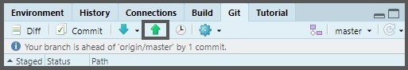

# Sync to a new GitHub repository From RStudio

According to the [Happy Git and GitHub guide](https://happygitwithr.com/new-GitHub-first.html#new-RStudio-project-via-git), the easiest way to sync to a new GitHub repository is to manually create and then clone your new repository from https://GitHub.com/. Doing this also establishes your remote connection, which allows you to immediately push or pull from your GitHub repository.

1. First, create a new repository from https://GitHub.com/.

[figure not shown]

2. Copy the SSH URL from GitHub (use the SSH connection as you have already set up your SSH keys in RStudio).

[figure not shown]

3. In RStudio, navigate to `File > New Project > Version Control > Git` and paste your SSH URL as the `Respository URL`. Doing so should automatically populate the name of your project directory (which should be the same name as your GitHub repository). Select a local location for your new project and create your project. I recommend creating a folder which houses all your local git repositories and always using this as your new project location.

[figure not shown]

**Note:** This step is equivalent to typing `git clone <SSH URL>` on the command line. The first time I tried to clone a new Github repository using RStudio, I received a fatal error message that RStudio could not read from the remote repository. I resolved this by cloning the remote repository from the command line, which allowed me to continue even though the authenticity of host ‘github.com’ could not be established. Doing so permanently added ‘github.com’ (RSA) to my list of known hosts and resolved the error.

4. Congratulations, you can now commit changes and push them to your remote GitHub repository!

[figure not shown]

# RStudio Git usage notes

- The RStudio Git GUI only works if you have an `.Rproj` file stored inside your local repository.

# Other resources

- A [guide](https://happygitwithr.com/RStudio-git-GitHub.html) to connecting RStudio to Git and GitHub by Jenny Bryan.
- A YouTube video on a [crash course to Git and GitHub from freeCodeCamp.org](https://www.youtube.com/watch?v=RGOj5yH7evk).
- A guide to solving a Git merge conflicts from [a presentation by Ariel Muldoon](https://aosmith16.GitHub.io/spring-r-topics/slides/week07_more_git.html#1).
- [GitHub documentation](https://docs.GitHub.com/en/GitHub/authenticating-to-GitHub/connecting-to-GitHub-with-ssh) on how to connect to GitHub with SSH.
- A tip on storing GitHub credentials from a [presentation by Charlotte Wickham](https://cwickham.GitHub.io/this-month-I-learned/#42).